# Lab12_SNC

Stephanie Call

11/16/2020

# Cytoscape tutorials

Cytoscape is an open source software that is used to visualize (not analyze) networks of interacting molecules, genes, biological pathways, etc. and integrate additional information into these networks, such as annotations, expression profiles, statistical significance of a measurement, and more. These can be integrated using a number of different formats, including changing the color of the node, weight of the connecting edges, highlighting specific nodes, subsetting a network based on certain criteria, and more. There are additional features available through Apps that can be downloaded.

The following network images were created by following the Cytoscape tutorials “Basic Data Visualization” and “Differentially Expressed Genes” (Team (2020)).

## Basic Data Visualization tutorial

After going through part of the “Basic Data Visualization” tutorial, I created the following large network (saved as a PNG) for the ‘galFiltered network with data’ data set.

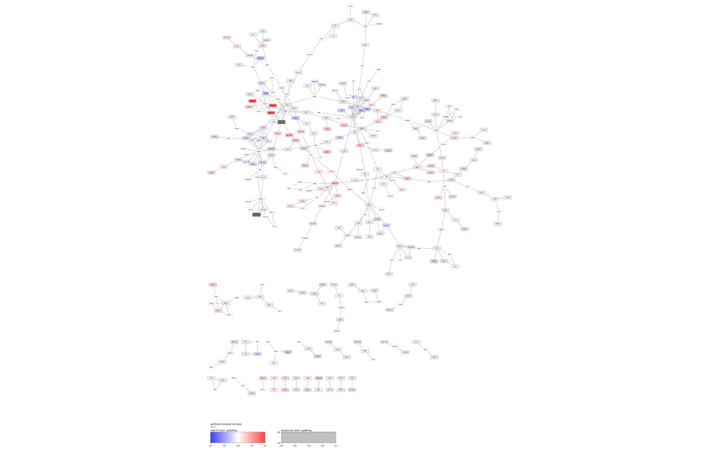

Very large network of the galFiltered network with data data set. The different colors are mapped to the differential expression level for each gene and the thickness of the border corresponds to a statistically significant difference. The network is laid out in a prefuse force-directed layout.

After selecting a small group of genes, the following small network was created.

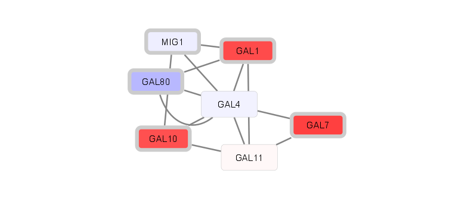

Selected genes with gal80 expression levels greater than 2 and their first neighbors. Mapping of node color and border thickness are the same as that in the previous image from this same tutorial.

## Differentially Expressed Genes tutorial

### Workflow 1 - Importing select genes from the STRING Database

The following networks shows the raw network (no GO processes mapping) and final network with the GO processes created from importing the up regulated genes from the gene set provided in the tutorial and applying the specified mappings. The genes were searched in the human STRING database using a protein query with a confidence score of at least 0.4, and the regulation data for all genes were imported from the table provided in the tutorial.

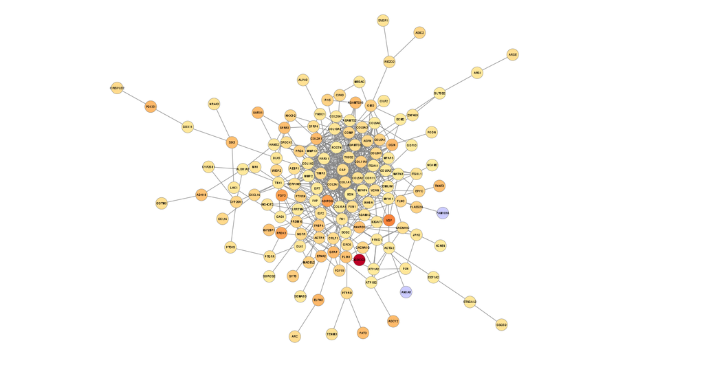

Network of up-regulated genes related to ovarian cancer. The color is mapped to the log fold change in expression level for the genes in ovarian cancer cells relative to a control expression level, with deeper shades of red indicating a stronger log fold change increase.

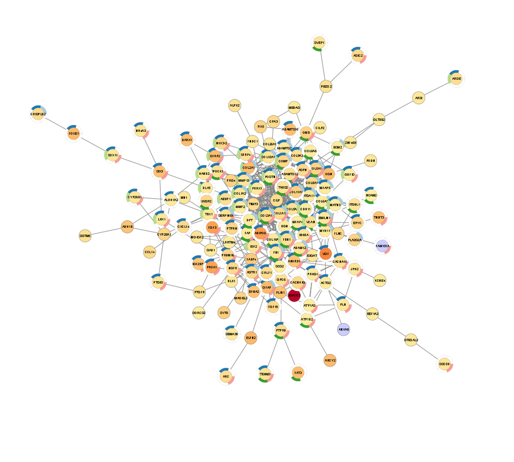

Network of up regulated genes related to ovarian cancer. The same color mapping is used in this network as the one directly above. In addition, the GO processes mapped to each gene through STRING enrichment analysis are shown as donut plots around each gene, with a different color corresponding to a different, non-redundant GO process..

The following networks shows the raw network and final network created from importing the down regulated genes from the gene set provided in the tutorial. The same data and mappings are applied as the up regulated genes except with a blue color mapping to indicate down regulation instead of up regulation.

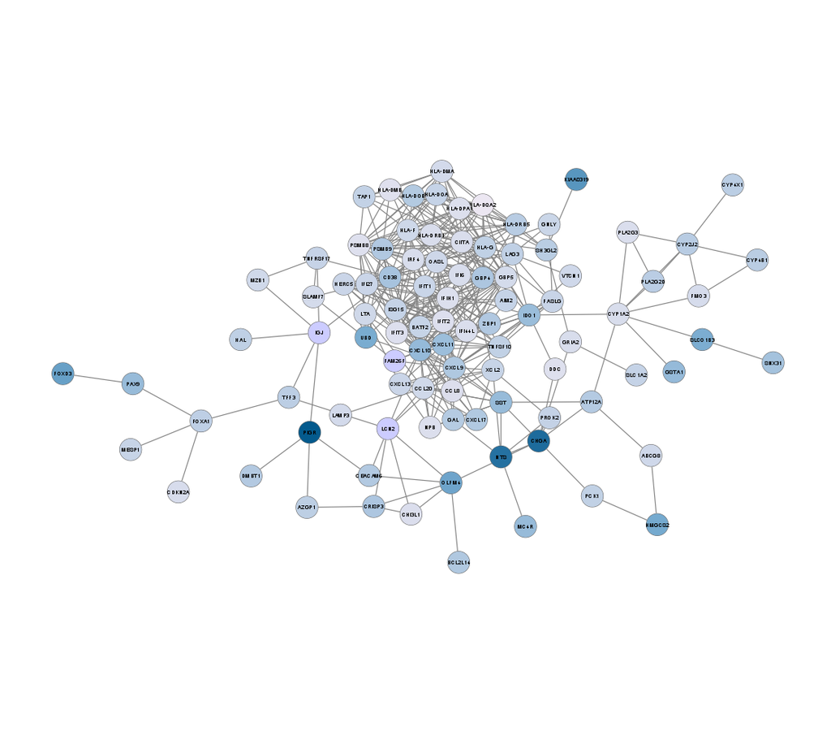

Network of down regulated genes related to ovarian cancer. The color is mapped to the log fold change in expression level for the genes in ovarian cancer cells relative to a control expression level, with deeper shades of blue indicating a stronger log fold change decrease.

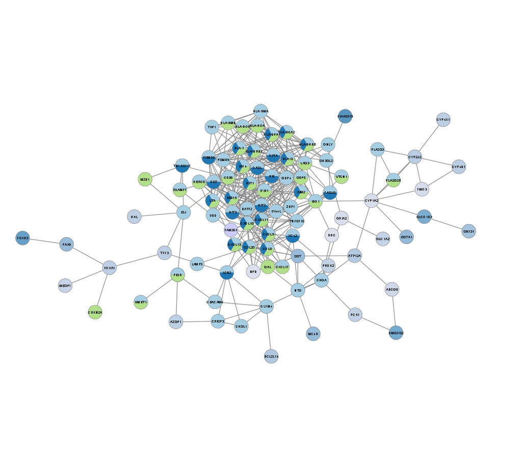

Network of down regulated genes related to ovarian cancer. The same color mapping in uses as the network directly above. In addition, the GO processes mapped to each gene from STRING enrichment analysis are shown as a pie chart in the node for each gene, with a different color indicating a different GO process. For this image, the node color mapping is still shown for each gene.

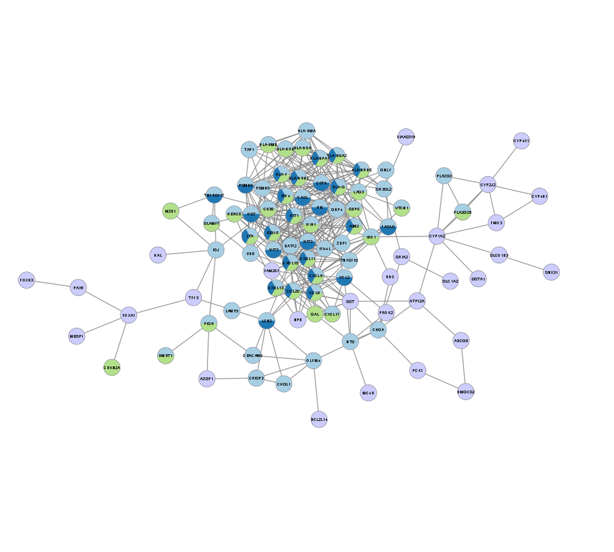

Network of down regulated genes related to ovarian cancer. This is the same network with the visualization of the same GO processes as the network directly above, except that the log fold change mapping to node color has been removed to more clearly see the different GO processes for each gene.

### Workflow 2 - Importing genes from the STRING Database using a key phrase

The following networks were created by searching ‘ovarian cancer’ in the Disease STRING Database and selecting the top 100 human genes with a confidence score of 0.95 or greater. As with Workflow 1, the expression data for the genes was imported from the table provided in the tutorial.

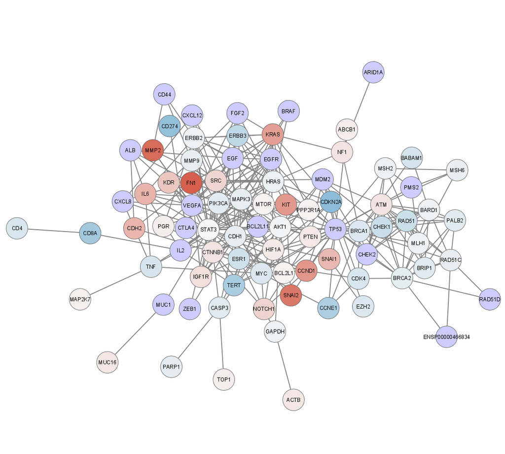

Network of top 100 genes related to ovarian cancer as determined through a keyword search in the Disease STRING Database with a cutoff confidence score of 0.95. The color of each node indicates the log fold change in expression of that gene in ovarian cancer cells relative to a control expression level, with deeper shades of blue indicating lower expression levels and deeper shades of red indicating higher expression levels.

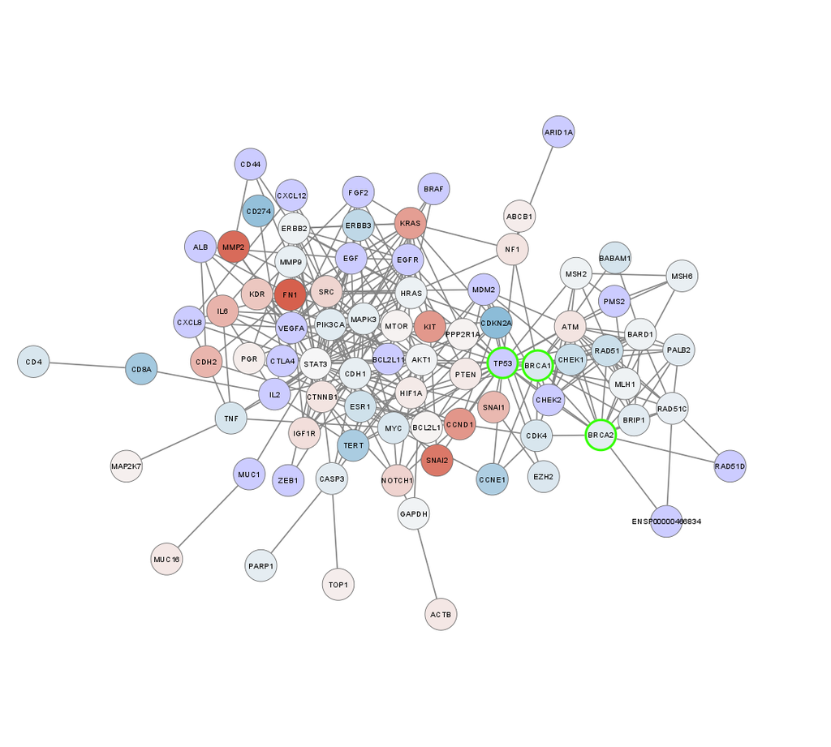

Network of top 100 genes related to ovarian cancer as determined through a keyword search in the Disease STRING Database with a cutoff confidence score of 0.95. The color of each node maps to the same differential expression level data as the network directly above. In addition, three important driver genes for that are commonly mutated in ovarian cancer are highlighted with a bright green border.

# Overview of RCy3

The following is the “Overview of RCy3” vignette for the RCy3 package (Pico et al. (2020)). RCy3 is a package that allows users to connect to Cytoscape from within R using CyREST, allowing graphs in R (including data frames) to be used to visualize and manipulate networks in Cytoscape in it’s own instance. R is essentially providing Cytoscape the data and telling how to visualize and manipulate the data. This allows for easily and quickly creating reproducible networks and manipulations and even incorporation into workflows.

## 1 - Installation

The installation is simply the same as any other BioConductor package and is shown here for completeness.

```r
if(!"RCy3" %in% installed.packages()) {
  install.packages("BiocManager")
  BiocManager::install("RCy3")
}
library(RCy3)
```

## 2 - Prerequisites

The RCy3 package requires Cytoscape 3.6.1 or greater. See the Cytoscape website to download the most recent version if necessary.

## 3 - Getting started

Before you can visualize anything with RCy3, you must first launch and keep Cytoscape running by calling the cytoscapePing() function. Calling this and the cytoscapeVersionInfo() function will ensure everything is installed correctly and running properly.

```r
cytoscapePing()
```

```
## [1] "You are connected to Cytoscape!"
```

```r
cytoscapeVersionInfo()
```

```
##       apiVersion cytoscapeVersion
##             "v1"          "3.8.2"
```

## 4 - My first network

A network can easily be created from two dataframe objects, one for the nodes and one for the edges, with the following specified formats and then imported to Cytoscape to visualize the network using the createNetworkFromDataFrames() function.

```r
nodes <- data.frame(id=c('node 0', 'node 1', 'node 2', 'node 3'),
                   group = c('A','A','B','B'), # Categorical strings for the node grouping
                   score = as.integer(c(20, 10, 15, 5)), # Integers for the node values
                   stringsAsFactors = FALSE)
edges <- data.frame(source=c('node 0', 'node 0', 'node 0', 'node 2'), # Start of edge
                    target = c('node 1', 'node 2', 'node 3', 'node 3'), # End of edge
                    interaction = c('inhibits', 'interacts', 'activates', 'interacts'), # Optional
                    weight = c(5.1, 3.0, 5.2, 9.9), # Numeric for line weights
                    stringsAsFactors = FALSE)

createNetworkFromDataFrames(nodes, edges, title = 'My first network',
                            collection = 'DataFrame Example')
```

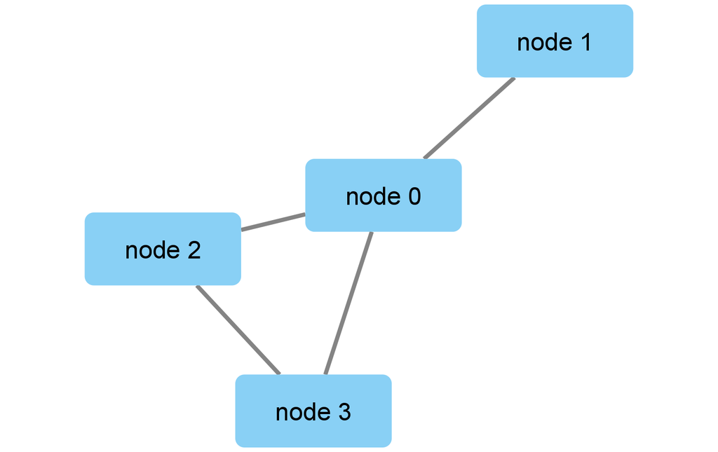

Default style for the network created from this simple dataframe

### 4.1 - Switch styles

Styles for the network created in Cytoscape can easily be selected from pre-made styles by calling the setVisualStyle() function with the specified pre-made style. For example, let’s change the style to Marquee. There is no need to recreate the network - it automatically updates after you apply the new style.

```r
setVisualStyle('Marquee')
```

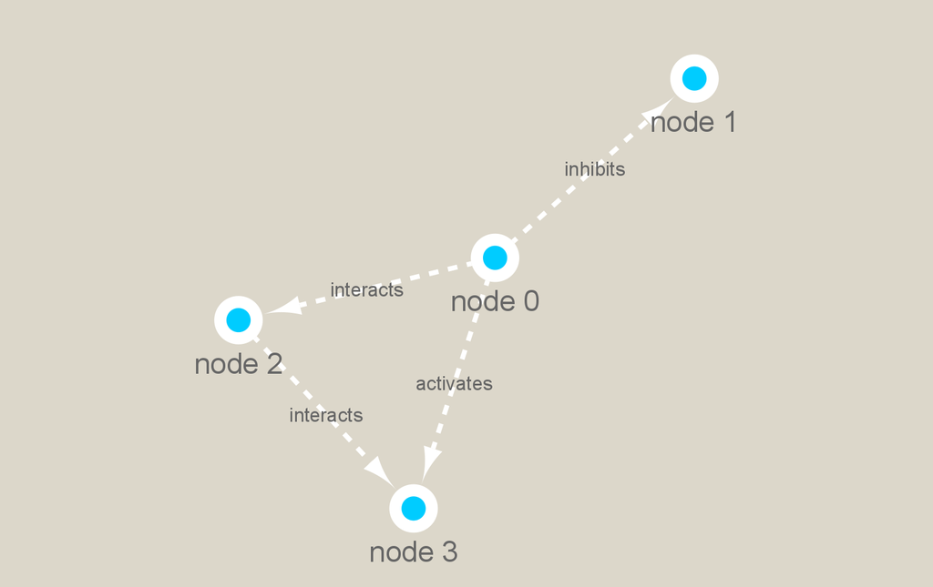

Built-in marquee style for the network created from the dataframe

### 4.2 - My own style

To create your own custom style, create some R objects that map node visual properties to new options using the mapVisualProperty() function for each property you want to customize. This function takes a visual property that you want to change, maps it to the column in the dataframe for that data, and applies new values for that property. See this functions documentation for much more details about the accepted properties to change, values for the properties, etc. for network visualization. After specifying these new properties, use the createVisualStyle() function with all properties (providing all the new mappings in a list) to create a custom style and apply it with setVisualStyle(). For example, create a new style and apply it to our simple network.

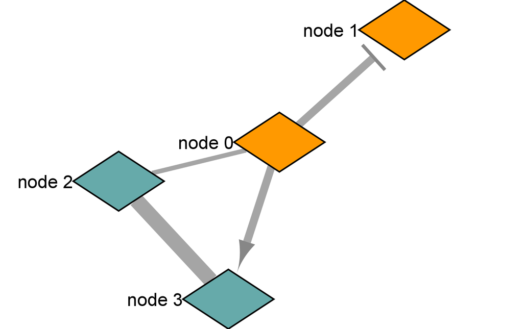

Customized style for the network created from the dataframe

```r
style.name <- 'myStyle'
defaults <- list(NODE_SHAPE = 'diamond',
                 NODE_SIZE = 30,
                 EDGE_TRANSPARENCY = 120,
                 NODE_LABEL_POSITION = 'W,E,c,0.00,0.00')
nodeLabels <- mapVisualProperty('node label', 'id', 'p')
nodeFills <- mapVisualProperty('node fill color', 'group', 'd', c('A', 'B'),
                               c('#FF9900', '#66AAAA'))
arrowShapes <- mapVisualProperty('Edge Target Arrow Shape', 'interaction', 'd',
                                 c('activates', 'inhibits', 'interacts'),
                                 c('Arrow', 'T', 'None'))
edgeWidth <- mapVisualProperty('edge width', 'weight', 'p')

createVisualStyle(style.name, defaults, list(nodeLabels, nodeFills, arrowShapes, edgeWidth))
setVisualStyle(style.name)
```

To set the NODE_WIDTH and NODE_HEIGHT properties independently of each other, you can unlock the node dimensions by specifying lockNodeDimensions(FALSE, style.name).

```r
lockNodeDimensions(FALSE, style.name)
```

## 5 - Bioconductor graph example

You can also make a network from a Bioconductor graphNEL object. For example, create a 4-node network in R as a graphNEL object and send it to Cytoscape for visualization and layout. To begin, don’t include any node attributes or styles. These topics are covered in the next steps.

```r
g <- new('graphNEL', edgemode = 'directed')
g <- graph::addNode('A', g)
g <- graph::addNode('D', g)
g <- graph::addNode('C', g, edges = list('D'))
g <- graph::addNode('B', g, edges = list(c('A', 'D', 'C')))
# No idea why, but it seems you can only make a single network in a knit file
# since trying to make two throws an error that 'no network view' is selected.
# For some wierd reason, it works in a script but not a knit RMarkdown doc.
createNetworkFromGraph(g, title = "Simple network", collection = 'GraphNEL Example')
```

```
## Loading data...
## Applying default style...
```

```
## Applying preferred layout...
```

```
## networkSUID
##          78
```

This should create a basic 4-node network with the default style. Cytoscape has built-in rendering rules that renders the nodes and edges with the default layout algorithm unless specified otherwise. Here is the image of the created network in the default style -

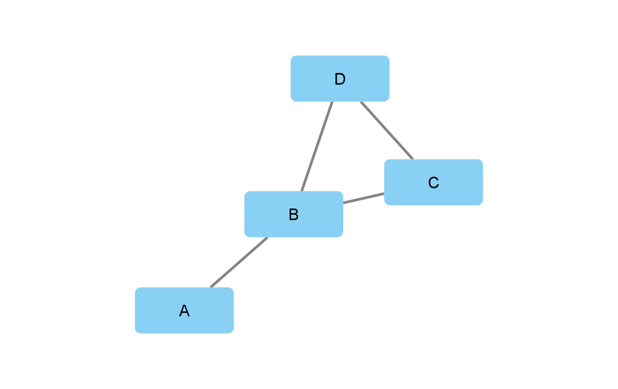

Simple network created from the graphNEL object using the default visual settings

### 5.1 - Add node attributes

In Cytoscape, we can map different properties of the data to the nodes of the network to more easily visualize and explore the data. There are many other properties that can be used to convey different data values in the network, such as the node shape, fill, line thickness, or size. For example, we can map the node fill to the type of gene that corresponds to each node, the differential expression ratio of that gene, or other property information about a particular node.

To continue with the simple 4-node graph we have created, let’s add two new data values to the nodes - moleculeType and log2fc. The easiest way to do so is through a data.frame object by adding the attributes to the data.frame object and importing the dataframe using loadTableData(). You can also include these attributes in the original graph models as Bioconductor graphs, igraphs, or data.frames and include the properties in the corresponding create functions to make the network. See the other vignettes for this package for more details on how to do so.

```r
df <- data.frame(moleculeType = c('kinase', 'TF', 'cytokine', 'cytokine'),
                 log2fc = c(1.8, 3.0, -1.2, -2.5),
                 row.names = c('A', 'B', 'C', 'D'), # row names = node names
                 stringsAsFactors = FALSE)
loadTableData(df)
```

```
## [1] "Success: Data loaded in defaultnode table"
```

Note that simply adding the attributes doesn’t cause the network appearance to change. You must specify and apply your desired visual style mappings to change the appearance of the graph. You can, however, see the added attributes in the Data Panel in Cytoscape to check that they were imported properly. This panel updates automatically to include the new attributes.

### 5.2 - Modifying the display: defaults and mappings

As shown above in making our own style, RCy3 provides an easy way to change the default styles and easily map properties of each data point to a visual style in a network, such as allowing the size, shape, and color of the nodes and edges to be determined by the data for each of these parts.

For demonstration, let’s first change some of the default properties of the network. This is done by a series of set[Property]Default() functions. See the documentation for the accepted values for each of the default visual properties.

```r
setNodeShapeDefault('OCTAGON')
```

```
## style.name not specified; updating "default" style.
```

```r
setNodeColorDefault('#AAFF88')
```

```
## style.name not specified; updating "default" style.
```

```r
setNodeSizeDefault(60)
```

```
## style.name not specified; updating "default" style.
## style.name not specified; updating "default" style.
```

```r
setNodeFontSizeDefault(30)
```

```
## style.name not specified; updating "default" style.
```

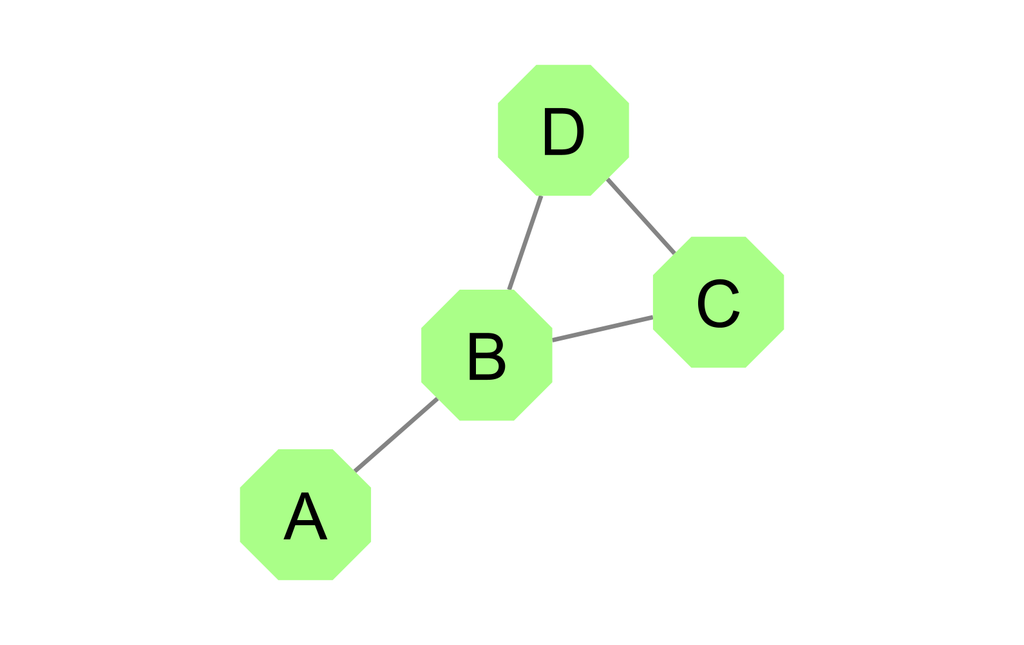

Simple graphNEL network after changing the default visual settings

Now, we will add some visual mappings to our 4-node network using the new data we input. We’ll map ‘moleculeType’ to the node shapes. First, determine the available shapes for Cytoscape using getNodeShapes(), then use the setNodeShapeMapping() to map the different values of moleculeType to different shapes. Similar set[Property]Mapping() functions exist for other visual properties that can be mapped to in a similar fashion.

```r
getNodeShapes() # Many options, including diamond, triangle, rectangle, ellipse, etc.
```

```
## [1] "ROUND_RECTANGLE" "TRIANGLE"        "RECTANGLE"       "HEXAGON"
## [5] "VEE"             "ELLIPSE"         "PARALLELOGRAM"   "OCTAGON"
## [9] "DIAMOND"
```

```r
column <- 'moleculeType'
values <- c('kinase', 'TF', 'cytokine')
shapes <- c('DIAMOND', 'TRIANGLE', 'RECTANGLE')
setNodeShapeMapping(column, values, shapes)
```

```
## style.name not specified; updating "default" style.
```

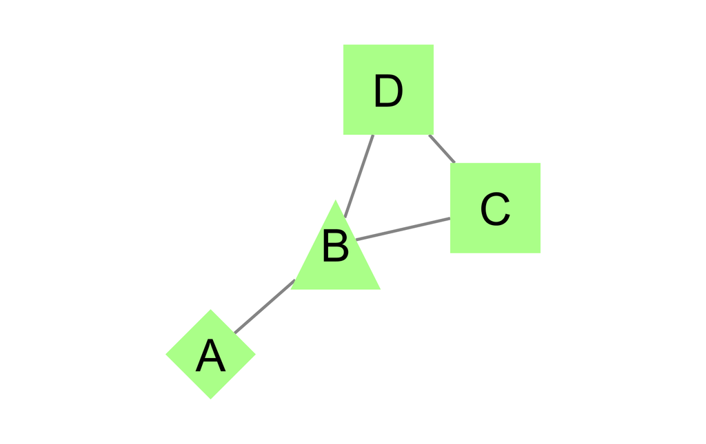

Simple graphNEL network after mapping the shape of the nodes to the type of molecule corresponding to each node

The node shape is an example of a discrete mapping, where the style is defined discretely for each distinct value. This is good for categorical data where there are a limited number of possible values. There are two other types of mappings that constrast with this discrete mapping: continuous and passthrough. Continuous is good for continuous data, or data where the values cover a range of numerical values. For the expression values in our example network, we want to use continuous mapping (to node color, here) since the expression values cover a range of numbers that change continuously. For continuous mapping, we define a small set of control points rather than explicit color values for each possible data point. Cytoscape simply interpolates the colors between the control points to create a color gradient that maps to the expression values. Now, let’s map the expression values to a color gradient in a similar way that we mapped the moleculeType to the node shape.

```r
column <- 'log2fc'
control.points <- c(-3.0, 0, 3.0)
colors <- c('#5588DD', '#FFFFFF', '#DD8855')
setNodeColorMapping(column, control.points, colors)
```

```
## style.name not specified; updating "default" style.
```

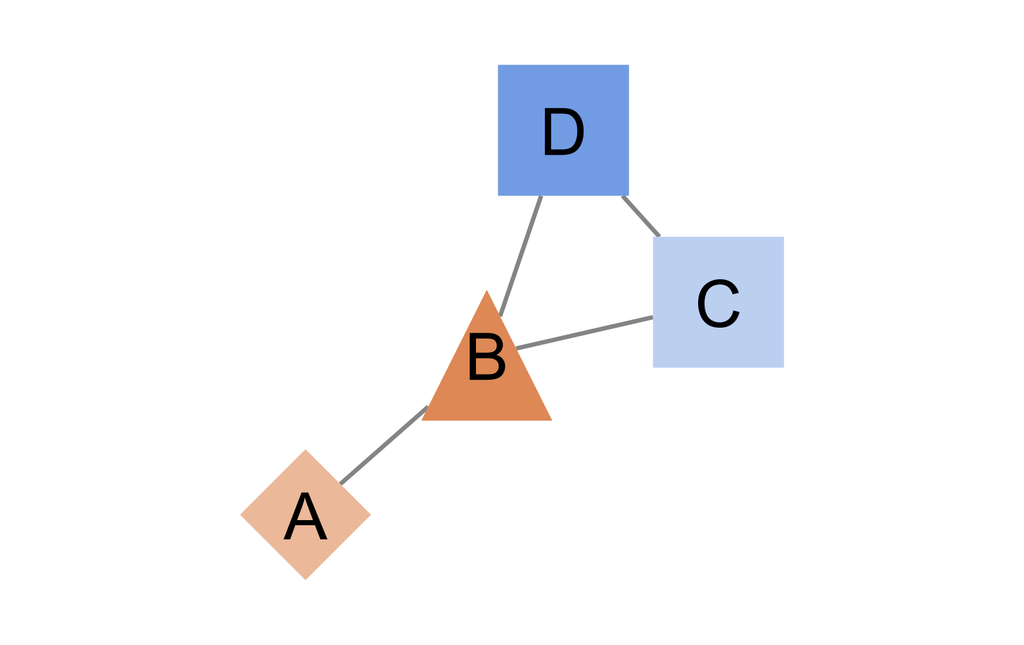

Simple graphNEL network after mapping the node colors to their corresponding log2fc value. All log2fc values are within the specified control points used to map the colors

Note how there are three colors and three control points. You can, however, specify two additional colors beyond the number of control points to set extreme (out-of-bounds) colors for values less or greater than the control points. The values should be specified before the lower set point for lower extreme value and after the higher set for the higher extreme value.

```r
control.points <- c(-2.0, 0, 2.0)
colors <- c('#2255CC', '#5588DD', '#FFFFFF', '#DD8855','#CC5522')
setNodeColorMapping (column, control.points, colors)
```

```
## style.name not specified; updating "default" style.
```

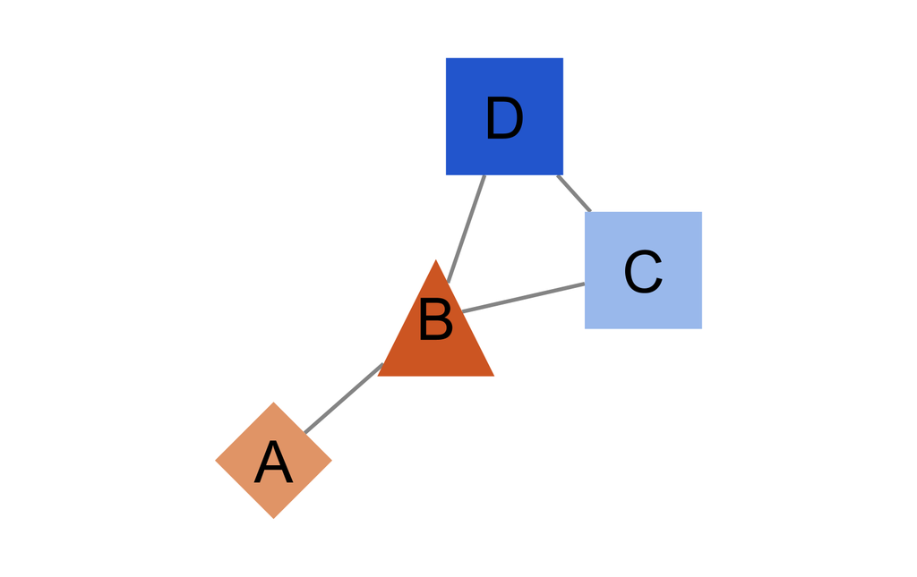

Simple graphNEL network after mapping the node colors to their corresponding log2fc value, this time with two extreme values for log2fc that are outside of the range of the control points used to map the colors. These colors are specified by the two additional colors in the mapping

Now, let’s add a node size mapping, using log2fc again to map to the node size. This is another continuous mapping in the same format as the node color.

```
## style.name not specified; updating "default" style.
```

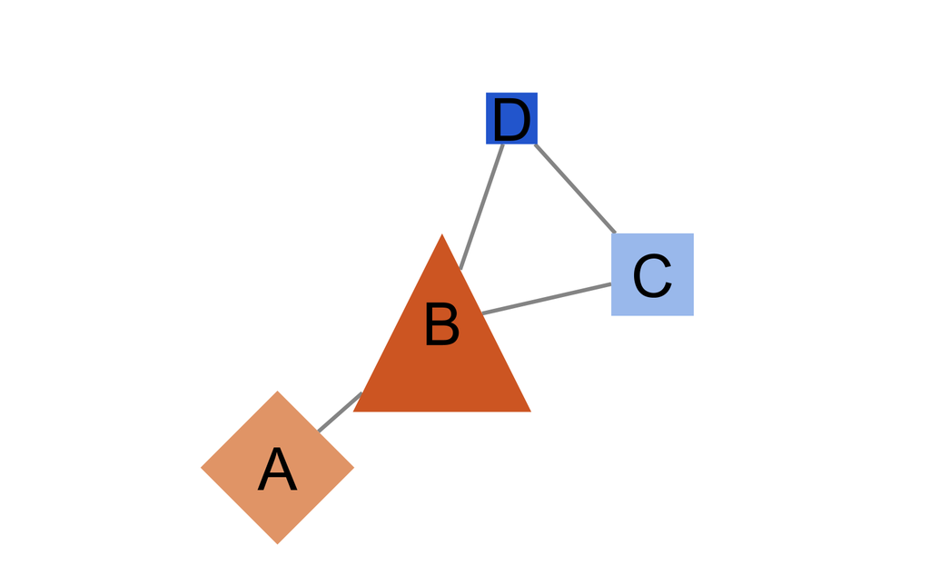

Simple graphNEL network after mapping the node size to their corresponding log2fc value

```r
control.points <- c(-3.0, 2.0, 3.0) # Note that the set points don't need to be symmetric
sizes <- c(20, 80, 90) # Nor do the values for the mappings
setNodeSizeMapping(column, control.points, sizes)
```

The third type of mapping, passthrough, is already working in our current example network as the node labels. By default, the ‘name’ column is mapped to the node label property using passthrough logic, as in the value is directly passed through to the style property (label is the same as the node name).

### 5.3 - Selecting nodes

Let’s try selecting some nodes in Cytoscape using R. This can be done directly using the selectNodes() function. To begin, let’s select the C node by name.

```r
selectNodes('C', 'name')
```

```
## $nodes
## [1] 90
##
## $edges
## list()
```

```r
getSelectedNodes()
```

```
## [1] "C"
```

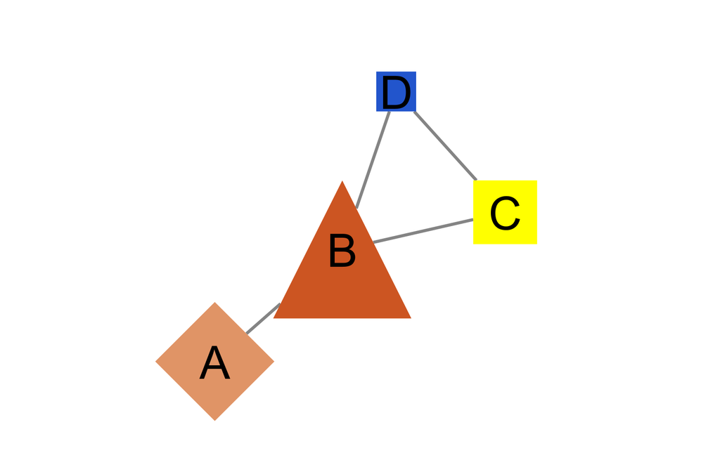

Simple graphNEL network with the C node selected

Now, let’s extend the selected nodes to include the first neighbors of the already-selected node C. This is a common operation in exploratory network analysis, such as exploring the interactions of nodes selected based on experimental data/annotation to see how these first interacting partners or upstream/downstream partners are affected. To select the first neighbors, use the selectFirstNeighbors() function.

```r
selectFirstNeighbors()
```

```
## $nodes
## [1] 89 90 91
##
## $edges
## list()
```

```r
getSelectedNodes()
```

```
## [1] "D" "C" "B"
```

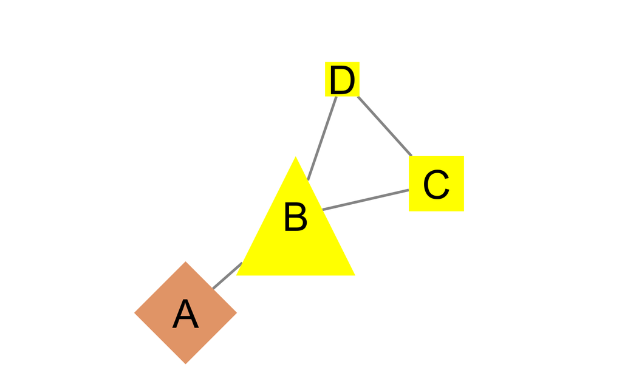

Simple graphNEL network with the C node and its first neighbors selected

You can now see that three nodes are selected. To get their names back in R as a list, simply call the getSelectedNodes() function and assign it to an object

```r
node.names <- getSelectedNodes()
node.names
```

```
## [1] "D" "C" "B"
```

Finally, to deselect nodes, use the clearSelection() function.

```r
clearSelection()
getSelectedNodes()
```

```
## No nodes selected.
```

```
## [1] NA
```

### 5.4 - Saving and export

Session files in Cytoscape save everything, so if they are opened later, the entire network and all manipulations made are loaded. As with most project software, you should always save often. The network session file made using RCy3 can be saved using the saveSession() function. This will save the file as the input name with the file extension .cys under the current working directory. You can also specify a complete path ending with the desired file name.

```r
saveSession('data/vignette_session') # Saves as a .cys file
```

### 5.4.1 - Saving high resolution image files

You can also export (save) high resolution images, including vector graphic formats, using the exportImage() function. See the exportImage() documentation (?exportImage()) for full details about the file formats for the images that can be saved.

```r
full.path <- paste(getwd(), 'data/vignette_image', sep = '/')
exportImage(full.path, 'PNG', zoom = 200) # Save a .png scaled by 200%
exportImage(full.path, 'PDF') # Save a .pdf image
```

Here is the PNG image saved from the last network -

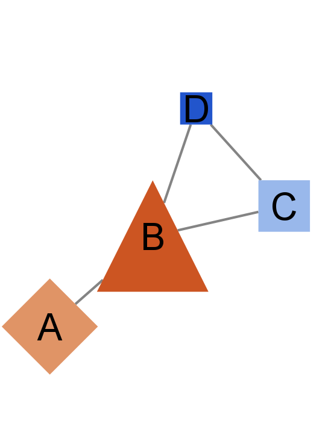

PNG image of last network saved using the exportImage() function.

## 6 - Browse available functions, commands, and arguments

RCy3 has many other functions and commands that can be used to interface with Cytoscape in many other ways, including accessing Apps in Cytoscape, manipulating layouts, filtering edges and nodes based on criteria, and more. These can be explored by reading the documentation.

```r
help(package = RCy3)
```

You can open swagger docs (a documentation of the API, application programming interface, between R and Cytoscape) for live instances of CyREST API and Commands API using the following commands -

```r
cyrestAPI()
commandsAPI()
```

To view the list of available commands and arguments for the commands in R, use the commandsHelp() function. Starting with ‘help’ for the top level commands, you can successfully call more commands in the output lists for more details about their arguments. For the commands past the first ‘help’ command, the ‘help’ is optional. For example, investigate the network select command using commandsHelp() starting at the top level commands.

```r
commandsHelp('help') # For top-level commands
```

```
## [1] "Available namespaces:"
```

```
##  [1] "analyzer"         "apps"             "command"          "cybrowser"
##  [5] "cychart"          "diffusion"        "edge"             "enhancedGraphics"
##  [9] "filter"           "group"            "idmapper"         "layout"
## [13] "network"          "node"             "session"          "string"
## [17] "table"            "view"             "vizmap"
```

```r
commandsHelp('help network') # For network commands.
```

```
## [1] "Available commands for 'network':"
```

```
##  [1] "add"              "add edge"         "add node"         "clone"
##  [5] "connect nodes"    "create"           "create attribute" "create empty"
##  [9] "delete"           "deselect"         "destroy"          "export"
## [13] "get"              "get attribute"    "get properties"   "hide"
## [17] "import file"      "import url"       "list"             "list attributes"
## [21] "list properties"  "load file"        "load url"         "merge"
## [25] "rename"           "select"           "set attribute"    "set current"
## [29] "set properties"   "show"
```

```r
commandsHelp('help network select') # View arguments for the network select command
```

```
## [1] "Available arguments for 'network select':"
```

```
## [1] "adjacentEdges"  "edgeList"       "extendEdges"    "firstNeighbors"
## [5] "invert"         "network"        "nodeList"
```

This short tutorial covers the basics for network manipulation using RCy3. More vignettes are available through the RCy3 BioConductor website and can be browsed using the browseVignettes(“RCy3”) command. Additionally, scripts are available at the Cytoscape GitHub repository for RCy3.

# References

Pico, Alexander, Tanja Muetze, Georgi Kolishovski, and Paul Shannon. 2020. “Overview of Rcy3.” Tutorial. 2020. https://bioconductor.org/packages/release/bioc/vignettes/RCy3/inst/doc/Overview-of-RCy3.html.

Team, Cytoscape. 2020. “Cytoscape Tutorials.” Tutorial. 2020. https://github.com/cytoscape/cytoscape-tutorials/wiki.